# Challenge 1: Energy Production Data Simulation

## Preparation

Load libraries:

```r
require(ggplot2, quiet = TRUE)
require(lubridate, quiet = TRUE)
```

Load data:

```r
training <- read.csv("../../data/training_dataset_500.csv")
```

## Exploration

First, let's see what we're dealing with:

```r
summary(training)
```

```
##        ID            Label        House          Year          Month
##  Min.   :    0   Min.   : 0   Min.   :  1   Min.   :2011   Min.   : 1.00
##  1st Qu.: 3000   1st Qu.: 5   1st Qu.:126   1st Qu.:2011   1st Qu.: 3.00
##  Median : 5999   Median :11   Median :250   Median :2012   Median : 7.00
##  Mean   : 5999   Mean   :11   Mean   :250   Mean   :2012   Mean   : 6.52
##  3rd Qu.: 8998   3rd Qu.:17   3rd Qu.:375   3rd Qu.:2012   3rd Qu.:10.00
##  Max.   :11998   Max.   :22   Max.   :500   Max.   :2013   Max.   :12.00
##   Temperature      Daylight   EnergyProduction
##  Min.   : 0.8   Min.   :134   Min.   : 254
##  1st Qu.: 5.3   1st Qu.:169   1st Qu.: 509
##  Median :13.2   Median :182   Median : 592
##  Mean   :14.4   Mean   :189   Mean   : 613
##  3rd Qu.:22.8   3rd Qu.:205   3rd Qu.: 698
##  Max.   :29.0   Max.   :271   Max.   :1254
```

```r
head(training)
```

```
##   ID Label House Year Month Temperature Daylight EnergyProduction
## 1  0     0     1 2011     7        26.2    178.9              740
## 2  1     1     1 2011     8        25.8    169.7              731
## 3  2     2     1 2011     9        22.8    170.2              694
## 4  3     3     1 2011    10        16.4    169.1              688
## 5  4     4     1 2011    11        11.4    169.1              650
## 6  5     5     1 2011    12         4.2    199.5              763
```

A bit of data cleaning:

```r
training$startdate <- ymd(paste(training$Year, training$Month, 1))
training$House <- factor(training$House)
```

And check for missing data:

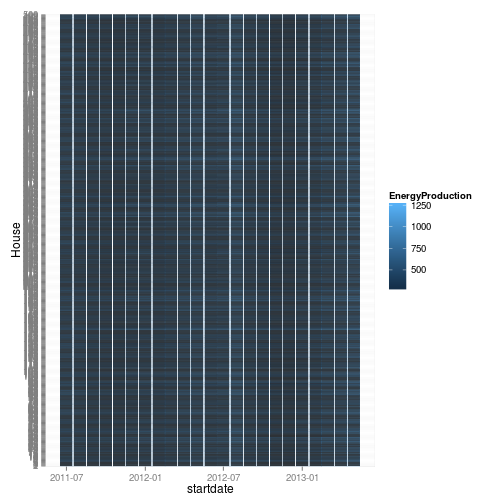

```r
ggplot(training) + geom_tile(aes(x = startdate, y = House, colour = EnergyProduction))
```

Doesn't look like we have missing data, but there appears to be a periodicity in the houses. If the labels are arbitrary, this shouldn't happen. Hopefully its just due to them having been sorted somehow before naming.

Let's look at some kernel density estimates:

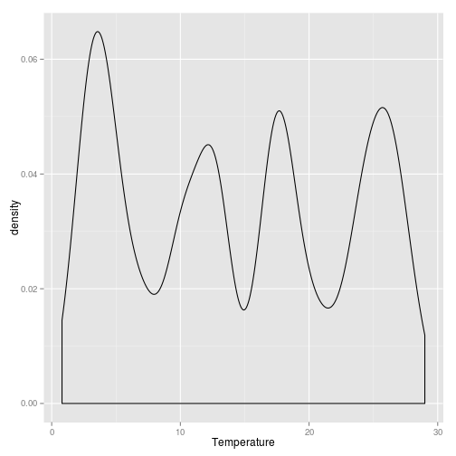

```r
densityplot <- ggplot(training) + geom_density()
densityplot + aes(x = Temperature)
```

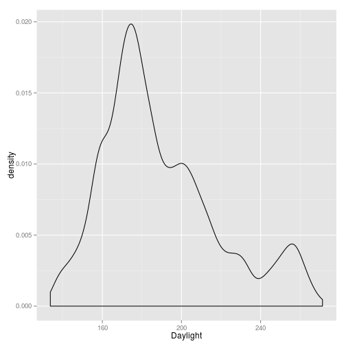

```r
densityplot + aes(x = Daylight)
```

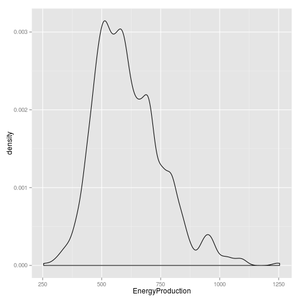

```r
densityplot + aes(x = EnergyProduction)
```

The density plot for `Temperature` is worryingly non-Gaussian, but I'll continue until this becomes a problem.

Now let's look at the correlations between `Temperature`, `Daylight` and `EnergyProduction`. I'm not sure exactly what `Daylight` measures, but I'd guess that it's correlated with `Temperature`. I also expect `EnergyProduction` to have some correlation with both.

```r
cor(training[, c("Temperature", "Daylight", "EnergyProduction")])
```

```
##                  Temperature Daylight EnergyProduction
## Temperature          1.00000 -0.05336           0.2728
## Daylight            -0.05336  1.00000           0.5316
## EnergyProduction     0.27279  0.53158           1.0000
```

`EnergyProduction` has the expected correlations, but the very low correlation between `Temperature` and `Daylight` is pretty surprising. One or both of these may not mean what I think it means.

## Prediction

### Some discussion

The first thing to do before modelling a system is to make sure you understand it, in particular the causes and effects.

Let's look at a few columns from the dataset:

But for now, let's ignore these issues, and build a quick linear model.

### A quick linear model

(Obviously testing on the training set like this is a bit taboo, but this is just exploration and overfitting isn't going to be an issue with a linear model over this kind of sample size)

```r
fit <- lm(EnergyProduction ~ Daylight + Temperature + I(abs(Month - 6)), data = training)
mean(abs(predict(fit, training) - training$EnergyProduction)/training$EnergyProduction)
```

```
## [1] 0.1333
```

This is fairly promising. We've used three variables: `Daylight`, `Temperature`, and 'summeriness' (number of months away from June), and we've got a MAPE of 13.3%. And this isn't specified to houses yet!

At this point, its worth noting that I'm choosing to make predictions conditional on the Daylight and Temperature readings. This seems to be the spirit of the problem, given that these values are included in the testing dataset. If we do not use these values, the bulk of the problem would essentially be weather forecasting.

### Including Houses

The baseline is now 13.3%, obtained by a linear model over all houses and environmental conditions. So now, we will include houses into the linear model.

```r
fit <- lm(EnergyProduction ~ House + Daylight + Temperature + I(abs(Month -
    6)), data = training)
mean(abs(predict(fit, training) - training$EnergyProduction)/training$EnergyProduction)
```

```
## [1] 0.05778
```

Wow, that really works. Looks like we're doing fine without anything fancy.

### Improving on 5.8%

To get better predictions, we've could move in two directions: improve the data, or improve how we model the data. In the past, I've generally found that improving data, or finding more data, is often better than making a model more 'sophisticated' (i.e. complicated).

TBC…

## Results

```r
testing <- read.csv("../../data/test_dataset_500.csv")
testing$House <- factor(testing$House)

MAPE <- mean(abs(predict(fit, testing) - testing$EnergyProduction)/testing$EnergyProduction) *
    100

print(MAPE)
```

```
## [1] 5.549
```

```r
writeLines(text = paste0("MAPE is ", round(MAPE, 3), "%"), con = "mape.txt")

predicted_energy_production <- data.frame(House = testing$House, EnergyProduction = predict(fit,
    testing))
write.csv(x = predicted_energy_production, file = "predicted_energy_production.csv")
```